# Rapport de groupe en Sciences des Données 2 + Bases de données

LOUATI Chamss-Eddine,

NDIAYE Ibrahima ,

EL OUALYDY Mohamed Amine,

SARTORI Adrien

03/04/2023

# Introduction

## Contexualisation

Le but de ce projet sera de voir:

**Quels sont les secteurs d’activités qui enregistrent les plus gros chiffres d’affaires et dans quelle région au cours de ces trois dernières années(2020,2021,2022) ?**

Pour ce faire, nous étudierons les chiffres d’affaires des entreprises aisni que leurs localisations.

Les données utilisées seront celles trouvées sur le site :

https://www.data.gouv.fr/fr/datasets/chiffres-cles-2022/

La question des secteurs d’ activities qui enregistrent les plus gros chiffres d’affaires revêt d’une grande importance pour un large éventail d’acteurs économiques, notamment les investisseurs, les entreprises, les gouvernements, les régulateurs et les consommateurs. Ainsi, l’actualité de cette question est constante car les secteurs qui enregistrent les plus gros chiffres d’affaires évoluent régulièrement en fonction des changements économiques, technologiques et sociaux. Par conséquent,les éléments de réponse à cette question pourront être utilisés pour des actions variées.

# Base de données

## Descriptif des tables

Notre base de données a été créée à partir d’un fichier appelé “Chiffres clés 2022” disponible sur le site web gouvernemental français “Data.gouv.fr”(https://www.data.gouv.fr/fr/datasets/chiffres-cles-2022/). Le fichier initial contenait 167 885 lignes et 42 colonnes. Après analyse et traitement des données, on a choisi de retenir trois tables principales pour notre étude.

- **Table_Activite**(5 colonnes, 443 lignes): Cette table a été créée pour mettre en évidence chaque secteur d’activité dans lequel l’entreprise appartient. On l’a réalisé en regroupant tous les secteurs d’activité pour faire la somme de leur chiffre d’affaire par année. Ce qui fait que dans cette table il n’y a pas de redondances au niveau de nos secteurs d’activité et que et pour chaque secteur on a le total de son chiffre d’affaire par années. Ainsi, elle est composée:
  - code d’activité(qui est de type **varchar** qui signifie caractère variable en francais),
  - secteur d’activite(**varchar**),
  - total chiffre d’affaire 2022(**bigint**, qui signifie gros entier en francais),
  - total chiffre d’affaire 2021(**bigint**),
  - total chiffre d’affaire 2020(**bigint**)
- **Table_Entreprise**(3.264 lignes,11 colonnes) : C’est notre table principale, où il y a le plus de colonnes et c’est la table où l’on retrouve toutes les caractéristiques de chaque entreprise:
  - identifiant de l’entreprise(**int**, qui signifie entier en francais),
  - nom de l’entreprise(**varchar**),
  - SIREN(**int**),
  - code_activite(**int**):clé étrangére référençant table_activite,
  - région (**varchar**), clé étrangére référençant table_region,
  - chiffre d’affaire 2022(**bigint**),
  - chiffre d’affaire 2021(**bigint**),
  - chiffre d’affaire 2020(**bigint**),
  - effectif 2022(**int**),
  - effectif 2021(**int**),
  - effectif 2022(**int**)
- **Table_Region**(17 lignes, 4 colonnes): Ici aussi, on a realisé presque le même calcul pour les secteurs d’activités, on a regroupé toutes les régions de toutes les entreprises, et on a effectué la somme de leur chiffre d’affaire pour chaque année. Voici nos colonnes:
  - nom de la region(**varchar**)
  - total chiffre d’affaire 2022(**bigint**)
  - total chiffre d’affaire 2021(**bigint**)
  - total chiffre d’affaire 2022(**bigint**)

En résumé, notre base de données a été construite à partir d’un fichier de données public, elle contient trois tables principales regroupant les chiffres d’affaires et les caractéristiques des entreprises étudiées, et elle est destinée à répondre à notre problématique de recherche des secteurs d’activités les plus performants en termes de chiffres d’affaires et de localisation.

## Modèles MCD et MOD

- MCD :

[figure not shown]

MCD.

- MOD:

[figure not shown]

**Legende:** Dans l’explication de notre MOD le signe **#** représente les **clés étrangéres** et les mots soulignés sont les **clés primaires**.

[figure not shown]

Explication du MOD.

## Import des données

- Le nettoyage des données a été réalisé sur Excel et Python(avec Pandas). Dans le fichier Chiffre clé 2022. Nous avons supprimé toutes les lignes comportants des valeurs manquantes. Pareillement, on a rectifié la forme d’écriture en UTF-8 pour rendre lisible nos données textuelles.
- Nous avons aussi filtré le fichier chiffre clé afin d’avoir nos trois tables. Ainsi, on a pu tirer la table Region en regroupant les regions de toutes les entreprises en faisant la somme de leur chiffre d’affaires pour chaque année avec l’aide de la bibliothéque pandas, puis on a effectué la même tâche pour avoir la table Activité.

## Quelques détails techniques

Nous utilisons ce script pour nous connecter à notre base de données :

```r
library(DBI)
library(RMySQL)
conn <- DBI::dbConnect(RMySQL::MySQL(),
                  user = "BDD_arrivedirt",
                  password = "df50a60dc58cfb65eefe321dcd88a5168dfd5083",
                  dbname = "BDD_arrivedirt",
                  host = "60d.h.filess.io",
                port=3307)
dbListTables(conn)
```

```
## [1] "table_activite"   "table_entreprise" "table_region"
```

Là, on fait un test SQL pour voir, si la connexion avec notre base données est bien établie:

```sql
show tables;
```

3 records

| Tables_in_BDD_arrivedirt |
| --- |
| table_activite |
| table_entreprise |
| table_region |

## Requêtes réalisées

**1)Quels sont les secteurs d’activités ayant enregistré la plus forte croissance de chiffre d’affaires au cours des trois dernières années(2020,2021,2022)?**

```sql
SELECT secteur_activite,
((total_ca_2022 - total_ca_2020)/total_ca_2020)*100 AS croissance
FROM table_activite
ORDER BY croissance DESC
LIMIT 10;"
```

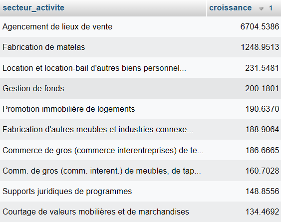

Question 1.

Dans cette requête, on sélectionne la colonne secteur d’activite et on calcule la croissance du chiffre d’affaires entre 2020 et 2022 en pourcentage en utilisant la formule suivante : ((total_ca_2022 - total_ca_2020) / total_ca_2020) * 100. Cela nous a permis de calculer le taux de croissance sur la période de 2020 à 2022. Les résultats sont triés par ordre décroissant de croissance et sont limités aux 10 premiers résultats pour illustrer secteurs d’activité ayant connu la croissance la plus importante.

**2)Dans quelles régions se trouvent les secteurs d’activités ayant enregistré la plus forte croissance de chiffre d’affaires entre 2020 et 2022?**

```sql
SELECT a.secteur_Activite, r.nom_region,
       (e.ca_2022 - e.ca_2020) AS croissance
FROM Table_Entreprise e
JOIN Table_Region r ON e.region = r.nom_region
JOIN table_activite a on e.code_Activite=a.code_Activite
ORDER BY croissance DESC
LIMIT 10;
```

[figure not shown]

Question 2.

Cette requête sélectionne les 10 entreprises dont la croissance du chiffre d’affaires entre 2020 et 2022 a été la plus importante. Elle relie les tables **Table_Entreprise**, **Table_Region** et **Table_Activite** pour obtenir le secteur d’activité de chaque entreprise ainsi que le nom de sa région. Le résultat de la requête affiche trois colonnes :

- “secteur_Activite” pour le secteur d’activité de l’entreprise
- “nom_region” pour le nom de la région où se situe l’entreprise
- “croissance” pour la différence entre le chiffre d’affaires de 2022 et celui de 2020 (positif si la croissance est positive, négatif sinon)

```sql
SELECT nom_region, SUM(total_ca_2020 + total_ca_2021
+ total_ca_2022) AS chiffre_affaires_total
FROM table_region
GROUP BY nom_region
ORDER BY chiffre_affaires_total DESC;
```

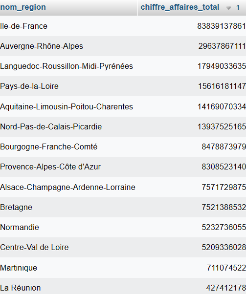

Question 3.

Cette requête permet de calculer le chiffre d’affaires total pour chaque région en faisant la somme des chiffres d’affaires pour les années 2020, 2021 et 2022.

La fonction SUM est utilisée pour additionner les chiffres d’affaires, tandis que la clause GROUP BY permet de regrouper les données par région. Enfin, la clause ORDER BY permet de trier les résultats en ordre décroissant de chiffre d’affaires total.

**4)Dans quelle région se trouvent les secteurs d’activités ayant enregistré les plus gros chiffres d’affaires au cours des trois dernières années(2020, 2021 et 2022)?**

```sql
SELECT nom_region, SUM(total_ca_2020 + total_ca_2021
+ total_ca_2022) AS chiffre_affaires_total
FROM table_region
GROUP BY nom_region
ORDER BY chiffre_affaires_total DESC
```

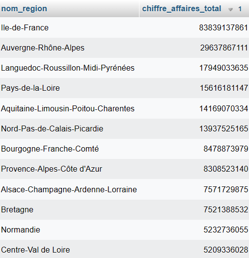

Question 4.

**5)Quelles sont les régions où se trouvent les entreprises ayant le plus gros chiffre d’affaires sur les trois dernières années(2020, 2021, 2022)?**

```sql
SELECT region,
       MAX(total_ca_2022) AS ca_2022,
       MAX(total_ca_2021) AS ca_2021,
       MAX(total_ca_2020) AS ca_2020
FROM Table_Region,table_entreprise
where Table_Region.nom_region = Table_Entreprise.region
GROUP BY region
ORDER BY ca_2022 DESC, ca_2021 DESC, ca_2020 DESC
LIMIT 10;
```

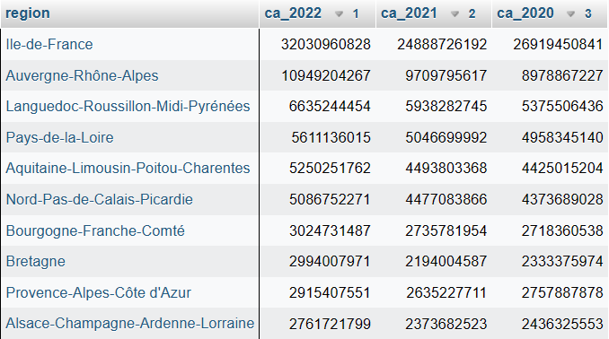

Question 5.

Dans cette requête, on utilise une jointure entre les tables Table_Region et Table_Entreprise pour regrouper les entreprises par région,puis on a calculé le chiffre d’affaire total pour chaque année. Ensuite, on a effectué la sélection des régions avec le chiffre d’affaires le plus élevé pour chaque année en utilisant la fonction d’agrégation **MAX**.Enfin,on ordonne les résultats par chiffre d’affaires décroissant en affichant que les résultats des 10 premières régions.